# A2 Permutation

Luke Ghallahorne

2025-01-22

# Packages

```r
# Library
## tidyverse for data tidying/management
library(tidyverse)
```

# The Case of the Crooked Die

If we roll a 6-sided die 60 times, we would expect to roll each number 1-6 approximately 10 times (with a probability of 1/6 per number). Given randomness, we wouldn’t necessarily expect to always roll exactly 10 of each, but we can use permutations to test whether the results we obtain are stochastic or weighted towards a particular number.

```r
rollSummary <- tibble(value=1:6,
                      n = c(8, 9, 18, 7, 8, 10))
rollSummary
```

```
## # A tibble: 6 × 2
##   value     n
##   <int> <dbl>
## 1     1     8
## 2     2     9
## 3     3    18
## 4     4     7
## 5     5     8
## 6     6    10
```

## Test Statistic - Chi-Squared

To determine if these rolls are the result of randomness, I will assign a Chi-Square test statistic to the original roll and each permutation.

```r
# number of total die rolls per test
nRolls <- 60

# expected values for each number on the die
Expected <- rep(10, 6)
# observed values
Observed <- rollSummary$n

# chi squared test statistic
obsXsq <- sum((Observed - Expected)^2 / Expected)
obsXsq
```

```
## [1] 8.2
```

The original data have a Chi-squared of 8.2.

## Permutation

From here, I will use a permutation test to build a distribution of expected Chi-squared values for multiple 60-roll tests. This repeats the 60 random rolls `m = 1000` times and calculates the Chi-squared test statistic for each test, then creates a distribution of likely Chi-squared values. We can then compare our original test statistic (8.2) to that distribution to determine how likely our original value is.

```r
# set seed for replicability
## pulls the same pseudo-random number string each time this code is run
set.seed(2336)
# number of times to repeat test
m <- 1000
possibleVals <- 1:6
# create empty vector to store permutation test statistics
chiSqVec <- vector()

# start permutation loop
for(i in 1:m) {
  # randomly sample values from 1-6, 60 times
  loopRolls <- tibble(value = sample(x = possibleVals, replace = TRUE,
                                     size = nRolls))
  # count interations of each value
  loopSumm <- loopRolls |>
    count(value)

  # pull observed counts for each value
  loopObs <- loopSumm$n

  # calculate chi-squared test statistic
  loopXsq <- sum((loopObs - Expected)^2 / Expected)

  # save loop chi-squared value to i'th index of empty vector
  chiSqVec[i] <- loopXsq
}
```

This loop repeats `m = 1000` times, with each iteration sampling 60 random dice rolls. For each, a chi-squared test statistic is calculated, then stored into a separate object for analysis.

## Distribution

Now we have our permutated Chi-squared values, we can make a distribution and assess where our original observed value lies in that distribution. That is, we use the simulated test statistics to model the distribution of Chi-squared under the null hypothesis that each value on the die has an equal chance of occurring. Furthermore, we can calculate an approximate p-value (the probability that we would get a more extreme test statistic) using the proportion of permutated values.

```r
# calculate p-value by counting all instances of chi squared greater than the observed, divided by the total number of tests
pval <- sum(chiSqVec > obsXsq) / m
pval
```

```
## [1] 0.14
```

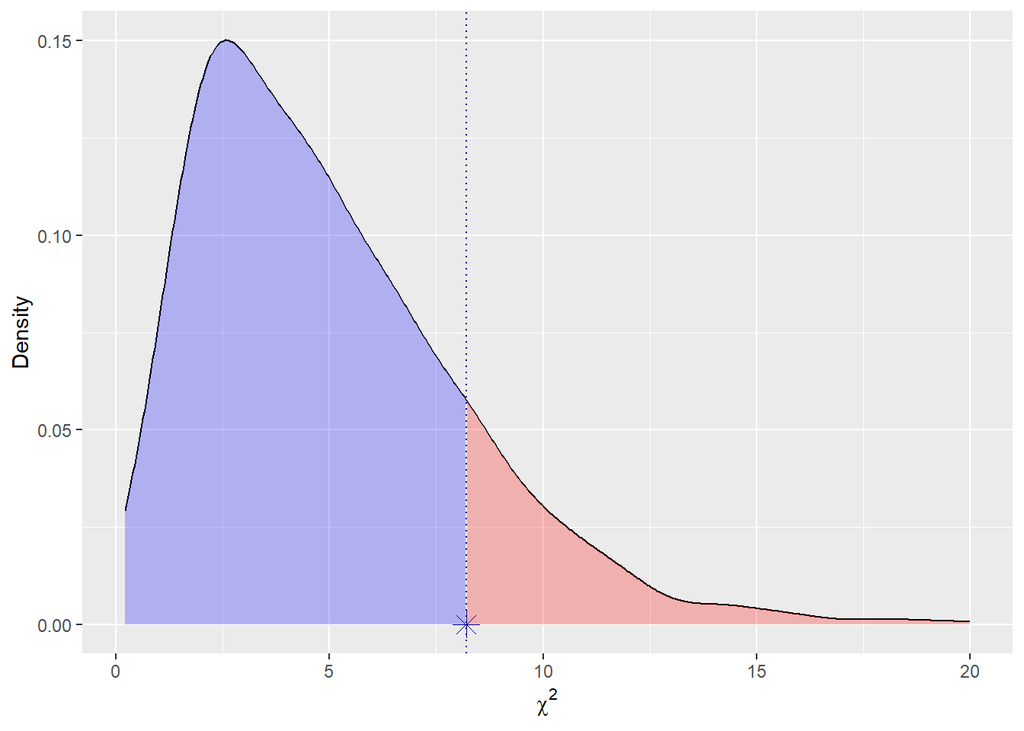

```r
# convert permutated chi-squared values into dataframe
perm_df <- tibble(chiSq = chiSqVec, sign = NA)

# create plot for density across all values
p1 <- ggplot(data = perm_df) +
  # density function
  geom_density(aes(x = chiSq))

# pull densities from ggplot object
## this is so I can color each half (below and above the observed value) separately
perm_dens <- ggplot_build(p1)$data[[1]]

p2 <- p1 +
  # color area above observed value
  geom_area(data = filter(perm_dens, x >= obsXsq),
            aes(x = x, y = y), fill = "red", alpha = 0.25) +
  geom_area(data = filter(perm_dens, x <= obsXsq),
            aes(x = x, y = y), fill = "blue", alpha = 0.25) +
  # original Observed value
  geom_point(data = tibble(chiSq = obsXsq),
             aes(x = chiSq, y = 0), color = "darkblue", size = 4, shape = 8) +
  geom_vline(aes(xintercept = obsXsq), linetype = 3, color = "darkblue") +
  # change labels and aesthetics for visualization
  xlab(expression(paste(chi^2))) +
  ylab("Density")
p2
```

Figure 1: Density distribution from a permutation test (m = 1000) of Chi-squared values for 60 rolls of a 6-sided die. Black line shows the proportional density at a given Chi-squared value. Dotted line and asterisk depict the originally observed Chi-squared. Blue shading indicates a Chi-squared lower than the observed; red shading indicates a Chi-squared greater than the observed.

Our permutation gives us a p-value of 0.14, decently above a rough alpha of 0.1 or 0.05. That is, 14% of the time, we would expect a random Chi-square from this test to be higher than our observed.